# Boston

# Chapter 3 - Exercise 15

This problem involves the Boston data set, which we saw in the lab for this chapter. We will now try to predict per capita crime rate using the other variables in this data set. In other words, per capita crime rate is the response, and the other variables are the predictors. (a) For each predictor, fit a simple linear regression model to predict the response. Describe your results. In which of the models is there a statistically significant association between the predictor and the response? Create some plots to back up your assertions.

```r
for (i in 2:13){
  print(names(Boston[i]))
  LM=lm(crim~Boston[,i])
  print(summary(LM))
}
```

```
[1] "zn"

Call:
lm(formula = crim ~ Boston[, i])

Residuals:
   Min     1Q Median     3Q    Max
-4.429 -4.222 -2.620  1.250 84.523

Coefficients:
            Estimate Std. Error t value Pr(>|t|)
(Intercept)  4.45369    0.41722  10.675  < 2e-16 ***
Boston[, i] -0.07393    0.01609  -4.594 5.51e-06 ***
---
Signif. codes:  0 ‘***’ 0.001 ‘**’ 0.01 ‘*’ 0.05 ‘.’ 0.1 ‘ ’ 1

Residual standard error: 8.435 on 504 degrees of freedom
Multiple R-squared:  0.04019,   Adjusted R-squared:  0.03828
F-statistic:  21.1 on 1 and 504 DF,  p-value: 5.506e-06

[1] "indus"

Call:
lm(formula = crim ~ Boston[, i])

Residuals:
    Min      1Q  Median      3Q     Max
-11.972  -2.698  -0.736   0.712  81.813

Coefficients:
            Estimate Std. Error t value Pr(>|t|)
(Intercept) -2.06374    0.66723  -3.093  0.00209 **
Boston[, i]  0.50978    0.05102   9.991  < 2e-16 ***
---
Signif. codes:  0 ‘***’ 0.001 ‘**’ 0.01 ‘*’ 0.05 ‘.’ 0.1 ‘ ’ 1

Residual standard error: 7.866 on 504 degrees of freedom
Multiple R-squared:  0.1653,    Adjusted R-squared:  0.1637
F-statistic: 99.82 on 1 and 504 DF,  p-value: < 2.2e-16

```

[output cut: 184 more lines]

```

Residuals:
   Min     1Q Median     3Q    Max
-9.071 -4.022 -2.343  1.298 80.957

Coefficients:
            Estimate Std. Error t value Pr(>|t|)
(Intercept) 11.79654    0.93419   12.63   <2e-16 ***
Boston[, i] -0.36316    0.03839   -9.46   <2e-16 ***
---
Signif. codes:  0 ‘***’ 0.001 ‘**’ 0.01 ‘*’ 0.05 ‘.’ 0.1 ‘ ’ 1

Residual standard error: 7.934 on 504 degrees of freedom
Multiple R-squared:  0.1508,    Adjusted R-squared:  0.1491
F-statistic: 89.49 on 1 and 504 DF,  p-value: < 2.2e-16
```

Best models are: indus, nox, age, dis, rad, tax, lsat and medv.

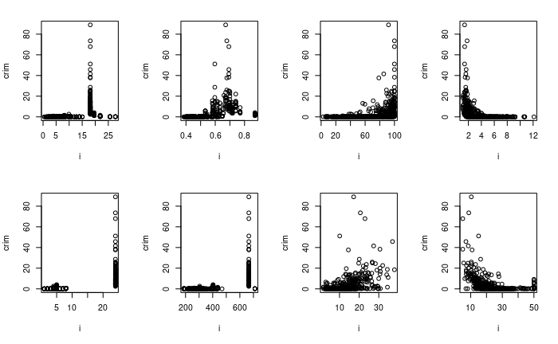

```r
varlist=list(indus, nox, age, dis, rad, tax, lstat, medv)

par(mfrow = c(2,4))
for (i in varlist){
  plot(i,crim)
}
```

2. Fit a multiple regression model to predict the response using all of the predictors. Describe your results. For which predictors can we reject the null hypothesis H 0 : β j = 0?

```r
A=lm(crim~zn+indus+chas+nox+rm+age+dis+rad+tax+ptratio+lstat+medv)
summary(A)
```

```
Call:
lm(formula = crim ~ zn + indus + chas + nox + rm + age + dis +
    rad + tax + ptratio + lstat + medv)

Residuals:
   Min     1Q Median     3Q    Max
-8.534 -2.248 -0.348  1.087 73.923

Coefficients:
              Estimate Std. Error t value Pr(>|t|)
(Intercept) 13.7783938  7.0818258   1.946 0.052271 .
zn           0.0457100  0.0187903   2.433 0.015344 *
indus       -0.0583501  0.0836351  -0.698 0.485709
chas        -0.8253776  1.1833963  -0.697 0.485841
nox         -9.9575865  5.2898242  -1.882 0.060370 .
rm           0.6289107  0.6070924   1.036 0.300738
age         -0.0008483  0.0179482  -0.047 0.962323
dis         -1.0122467  0.2824676  -3.584 0.000373 ***
rad          0.6124653  0.0875358   6.997 8.59e-12 ***
tax         -0.0037756  0.0051723  -0.730 0.465757
ptratio     -0.3040728  0.1863598  -1.632 0.103393
lstat        0.1388006  0.0757213   1.833 0.067398 .
medv        -0.2200564  0.0598240  -3.678 0.000261 ***
---
Signif. codes:  0 ‘***’ 0.001 ‘**’ 0.01 ‘*’ 0.05 ‘.’ 0.1 ‘ ’ 1

Residual standard error: 6.46 on 493 degrees of freedom
Multiple R-squared:  0.4493,    Adjusted R-squared:  0.4359
F-statistic: 33.52 on 12 and 493 DF,  p-value: < 2.2e-16
```

Less significant values in the total model are indus, chas, rm, age, tax and ptratio.

3. How do your results from (a) compare to your results from (b)? Create a plot displaying the univariate regression coefficients from (a) on the x-axis, and the multiple regression coefficients from (b) on the y-axis. That is, each predictor is displayed as a single point in the plot. Its coefficient in a simple linear regression model is shown on the x-axis, and its coefficient estimate in the multiple linear regression model is shown on the y-axis.

With all predictors, the important ones are rad, dis and medv, with where some of the previously mentioned.

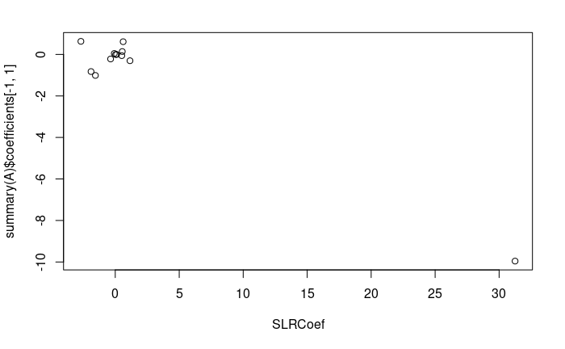

```r
SLRCoef=c()
for (i in 2:13){
  LM=lm(crim~Boston[,i])
  SLRCoef=c(SLRCoef,summary(LM)$coefficients[-1,1])
}
plot(SLRCoef,summary(A)$coefficients[-1,1])
```

nox is the one.

4. Is there evidence of non-linear association between any of the predictors and the response? To answer this question, for each predictor X, fit a model of the form Y = β_0 + β_1 X + β_2 X^2 + β_3 X^3 + e.

```r
for (i in (2:13)){
  print(names(Boston[i]))
  B <- lm(crim~Boston[,i]+I(Boston[,i]^2)+I(Boston[,i]^3))
  print(summary(B))
}
```

```
[1] "zn"

Call:
lm(formula = crim ~ Boston[, i] + I(Boston[, i]^2) + I(Boston[,
    i]^3))

Residuals:
   Min     1Q Median     3Q    Max
-4.821 -4.614 -1.294  0.473 84.130

Coefficients:
                   Estimate Std. Error t value Pr(>|t|)
(Intercept)       4.846e+00  4.330e-01  11.192  < 2e-16 ***
Boston[, i]      -3.322e-01  1.098e-01  -3.025  0.00261 **
I(Boston[, i]^2)  6.483e-03  3.861e-03   1.679  0.09375 .
I(Boston[, i]^3) -3.776e-05  3.139e-05  -1.203  0.22954
---
Signif. codes:  0 ‘***’ 0.001 ‘**’ 0.01 ‘*’ 0.05 ‘.’ 0.1 ‘ ’ 1

Residual standard error: 8.372 on 502 degrees of freedom
Multiple R-squared:  0.05824,   Adjusted R-squared:  0.05261
F-statistic: 10.35 on 3 and 502 DF,  p-value: 1.281e-06

[1] "indus"

Call:
lm(formula = crim ~ Boston[, i] + I(Boston[, i]^2) + I(Boston[,
    i]^3))

Residuals:
   Min     1Q Median     3Q    Max
-8.278 -2.514  0.054  0.764 79.713

Coefficients:
                   Estimate Std. Error t value Pr(>|t|)
(Intercept)       3.6625683  1.5739833   2.327   0.0204 *
Boston[, i]      -1.9652129  0.4819901  -4.077 5.30e-05 ***
I(Boston[, i]^2)  0.2519373  0.0393221   6.407 3.42e-10 ***
I(Boston[, i]^3) -0.0069760  0.0009567  -7.292 1.20e-12 ***
---
```

[output cut: 216 more lines]

```
    Min      1Q  Median      3Q     Max
-15.234  -2.151  -0.486   0.066  83.353

Coefficients:
                   Estimate Std. Error t value Pr(>|t|)
(Intercept)       1.2009656  2.0286452   0.592   0.5541
Boston[, i]      -0.4490656  0.4648911  -0.966   0.3345
I(Boston[, i]^2)  0.0557794  0.0301156   1.852   0.0646 .
I(Boston[, i]^3) -0.0008574  0.0005652  -1.517   0.1299
---
Signif. codes:  0 ‘***’ 0.001 ‘**’ 0.01 ‘*’ 0.05 ‘.’ 0.1 ‘ ’ 1

Residual standard error: 7.629 on 502 degrees of freedom
Multiple R-squared:  0.2179,    Adjusted R-squared:  0.2133
F-statistic: 46.63 on 3 and 502 DF,  p-value: < 2.2e-16
```

```r
#B=lm(crim~Boston[,2]+I(Boston[,2]^2)+I(Boston[,2]^3))
#  print(names(Boston[2]))
#  summary(B)
```

It seems there is a nonlinear relationship with indus, nox and dis.

# Chapter 4 - Exercise 16

Using the Boston data set, fit classification models in order to predict whether a given census tract has a crime rate above or below the median. Explore logistic regression, LDA, naive Bayes, and KNN models using various subsets of the predictors. Describe your findings. Hint: You will have to create the response variable yourself, using the variables that are contained in the Boston data set.

```r
#mass library
library(MASS)
```

```r
#Create variable and data frame
M=median(crim)
crim01 <- rep(1, length(crim))
crim01[crim<median(crim)]=0
Boston2 <- data.frame(Boston, crim01)

#Spliting training data
#take a sample
x<-sample(c(1:length(crim)), round(0.7*length(crim)))

train <- Boston2[x,]

Boston2.test <- Boston2[-x,]
crim01.test <- crim01[-x]
```

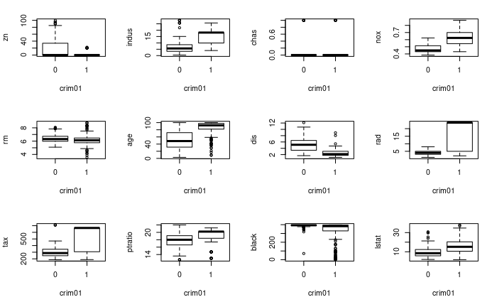

```r
par (mfrow = c(3, 4))
for (i in 2:13){
  plot(as.factor(crim01),Boston2[,i],ylab=names(Boston2[i]),xlab="crim01")
}
```

Logistic Regression

```r
LR=glm(crim01~zn+rm+dis, data=Boston2, family=binomial, subset=x)
summary(LR)
```

```
Call:
glm(formula = crim01 ~ zn + rm + dis, family = binomial, data = Boston2,
    subset = x)

Deviance Residuals:
    Min       1Q   Median       3Q      Max
-2.0051  -0.5345  -0.0122   0.6718   1.9934

Coefficients:
            Estimate Std. Error z value Pr(>|z|)
(Intercept)  2.78049    1.37941   2.016  0.04383 *
zn          -0.04957    0.01918  -2.584  0.00977 **
rm           0.12402    0.21485   0.577  0.56377
dis         -0.98321    0.12206  -8.055 7.93e-16 ***
---
Signif. codes:  0 ‘***’ 0.001 ‘**’ 0.01 ‘*’ 0.05 ‘.’ 0.1 ‘ ’ 1

(Dispersion parameter for binomial family taken to be 1)

    Null deviance: 490.47  on 353  degrees of freedom
Residual deviance: 295.43  on 350  degrees of freedom
AIC: 303.43

Number of Fisher Scoring iterations: 7
```

```r
LR.Prob=predict(LR,Boston2.test, type='response')
LR.pred =rep (0, length(crim01.test))
LR.pred[LR.Prob>.5] = 1
table(LR.pred, crim01.test)
```

```
       crim01.test
LR.pred  0  1
      0 51 15
      1 20 66
```

```r
mean(LR.pred != crim01.test)
```

```
[1] 0.2302632
```

LDA

```r
lda.fit=lda(crim01 ~ zn+rm+dis, data=Boston2, subset=x)
lda.pred <- predict(lda.fit, Boston2.test)
lda.class <- lda.pred$class

table(lda.class, crim01.test)
```

```
         crim01.test
lda.class  0  1
        0 49 11
        1 22 70
```

```r
mean(lda.class!=crim01.test)
```

```
[1] 0.2171053
```

QDA

```r
qda.fit=qda(crim01~zn+rm+dis, data=Boston2, subset=x)
qda.pred <- predict(qda.fit, Boston2.test)
qda.class <- qda.pred$class

table(qda.class, crim01.test)
```

```
         crim01.test
qda.class  0  1
        0 44  4
        1 27 77
```

```r
mean(qda.class!=crim01.test)
```

```
[1] 0.2039474
```

Naive Bayes

```r
library(e1071)
NB=naiveBayes(crim01~rm+zn+dis, data=Boston2, subset=x)
NB.pred=predict(NB, Boston2.test)
table(NB.pred, crim01.test)
```

```
       crim01.test
NB.pred  0  1
      0 43  4
      1 28 77
```

```r
mean(NB.pred!=crim01.test)
```

```
[1] 0.2105263
```

KNN

```r
library(class)
train.X <- cbind (rm,dis,zn) [x,]
test.X <- cbind (rm,dis,zn) [-x,]
train.crim01 <- crim01[x]
set.seed (1)
for (i in 1:100){
  KNN.pred=knn(train.X, test.X, train.crim01, k=i)
  table(KNN.pred, crim01.test)
  if (mean(KNN.pred != crim01.test) <= 0.19){
    print(i)
    print(mean(KNN.pred != crim01.test))
  }
}
```

```
[1] 28
[1] 0.1842105
[1] 31
[1] 0.1842105
[1] 32
[1] 0.1842105
```

First of all, we take the sample with 70% of the data. Secondly, we plot the variables against the response to decide which variables we are going to use. Finally, we fit and predict with several models and compare the error rate. The lowest error rate is achieved with KNN and K=28, 31 or 32. QDA also has lower error rate than the other methods.

# Chapter 5 - Exercise 9

We will now consider the Boston housing data set, from the ISLR2 library. (a) Based on this data set, provide an estimate for the population mean of medv . Call this estimate ^μ.

```r
set.seed(1)
#n=length(Boston[,1])/2
#train5.9 <- sample(length(Boston[,1]), n)
#Boston.test<- Boston[-train5.9,]
mu=mean(Boston$medv)
mu
```

```
[1] 22.53281
```

2. Provide an estimate of the standard error of μ̂. Interpret this result. Hint: We can compute the standard error of the sample mean by dividing the sample standard deviation by the square root of the number of observations.

```r
sterr=sd(Boston$medv)/sqrt(length(Boston[,1]))
sterr
```

```
[1] 0.4088611
```

3. Now estimate the standard error of ^μ using the bootstrap. How does this compare to your answer from (b)?

```r
library(boot)
```

```r
set.seed(1)
mean.medv <-function(data=Boston, index){mean(Boston$medv[index])}

Bmu=boot(data=Boston, statistic=mean.medv, R=1000)
Bmu
```

```
ORDINARY NONPARAMETRIC BOOTSTRAP


Call:
boot(data = Boston, statistic = mean.medv, R = 1000)


Bootstrap Statistics :
    original      bias    std. error
t1* 22.53281 0.007650791   0.4106622
```

The std error given by the bootstrap is a bit higher than the estimation in (b).

4. Based on your bootstrap estimate from (c), provide a 95 % confidence interval for the mean of medv . Compare it to the results obtained using t.test(Boston$medv) . Hint: You can approximate a 95 % confidence interval using the formula [μ̂ − 2SE(μ̂), μ̂ + 2SE(μ̂)].

```r
IC=c(mu-2*sd(Bmu$t),mu+2*sd(Bmu$t))
IC
```

```
[1] 21.71148 23.35413
```

```r
t.test(Boston$medv)
```

```
    One Sample t-test

data:  Boston$medv
t = 55.111, df = 505, p-value < 2.2e-16
alternative hypothesis: true mean is not equal to 0
95 percent confidence interval:
 21.72953 23.33608
sample estimates:
mean of x
 22.53281
```

The confidence interval given by the bootstrap is wider than the given by t.test(Boston$medv) because the std error is higher in bootstrap (See (c)).

5. Based on this data set, provide an estimate, μ̂ med , for the median value of medv in the population.

```r
set.seed(1)
median.fn <- function(data,index){return(median(data[index]))}

boot(Boston$medv, median.fn, 1000)
```

```
ORDINARY NONPARAMETRIC BOOTSTRAP


Call:
boot(data = Boston$medv, statistic = median.fn, R = 1000)


Bootstrap Statistics :
    original  bias    std. error
t1*     21.2 0.02295   0.3778075
```

6. We now would like to estimate the standard error of μ̂ med . Unfortunately, there is no simple formula for computing the standard error of the median. Instead, estimate the standard error of the median using the bootstrap. Comment on your findings.

The standard error for the median is

```r
sd(Bmed$t)
```

[output not shown]

7. Based on this data set, provide an estimate for the tenth percentile of medv in Boston census tracts. Call this quantity μ̂ 0.1.(You can use the quantile() function.)

```r
mu0.1=quantile(Boston$medv, 0.1)
mu0.1
```

```
  10%
12.75
```

8. Use the bootstrap to estimate the standard error of μ̂ 0.1 . Comment on your findings.

```r
set.seed(1)
q.fn<-function(data=Boston, index){quantile(Boston$medv[index], 0.1)}
Bq=boot(data=Boston, statistic=q.fn, R=1000)
Bq
```

```
ORDINARY NONPARAMETRIC BOOTSTRAP


Call:
boot(data = Boston, statistic = q.fn, R = 1000)


Bootstrap Statistics :
    original  bias    std. error
t1*    12.75  0.0339   0.4767526
```